# Applied Genomics 2024 HW6

Lauren Shelby

### Data source

The data provided from this assignment is from single cell RNA-seq of primary human peripheral blood immune cells from this study (GSE134757). The original data has 10,000 cells that I have downsampled to 3000 so the data size is more manageable. Your task for this assignment is to follow the Seurat workflow to filter the data, normalize, scale, identify clusters, and gene markers that define the cell clusters.

###0. Install, if necessary, and load the following packages: Seurat, dplyr, patchwork

```r
# Loading the Seurat, dplyr, and patchwork packages with library()
library(Seurat)
library(dplyr)
library(patchwork)
```

## Data loading and object creation

###1. Load the counts file, use the gene column as row names and show the first 5 row and columns (5 pts)

```r
# Loading in the counts file, and the gene names go automatically as the row names
counts <- read.delim("GSE134757_hPB_rawcounts_downsampled.tsv")
# Displaying the first 5 rows and columns of the counts data frame
head(counts, n=c(5,5))
```

|  | PB.CATGCTCTCTGCTAGA | PB.TGACGCGAGACGGTTG | PB.TCATTGTGTGCTTATG | PB.CTTGAGAAGGTAGTCG | PB.GGAGCAAGTATCATGC |
| --- | --- | --- | --- | --- | --- |
| A1BG | 1 | 0 | 0 | 1 | 0 |
| A1BG-AS1 | 0 | 0 | 0 | 0 | 0 |
| A2M | 0 | 0 | 0 | 0 | 0 |
| A2M-AS1 | 0 | 0 | 0 | 0 | 0 |
| A4GALT | 0 | 0 | 0 | 0 | 0 |

###2. Load the Seurat package; install first if necessary. create a seurat object named phpb (5 pts)

```r
# Creating a Seurat object (loaded above) named phpb
# counts = count matrix in Seurat object
# min.cells = keep only genes that have some expression value in at least # number of cells
# min.features = keep only cells that have expression of at least # number of genes
# Above specifications are to filter out cells that have expression counts that aren't very impactful
phpb <- CreateSeuratObject(counts=counts, min.cells = 3, min.features = 200)
```

## Quality control and data filtering

###3. Annotate the mitochondrial genes. create a new column in the phpb object named “percent.mt” that hold the % of features that are mitochondrial (5 pts)

```r
# Creating column in phpb object called 'percent.mt' to hold % of mitochondrial features to see the degree to which these genes are impacting the expression data in the cells
phpb[["percent.mt"]] <- PercentageFeatureSet(phpb, pattern = "^MT-")
```

###4. Let’s visualize the distribution of some QC metrics. Use VlnPlot to view number of counts, number of features, and the percent mitochondrial genes. (10 pts)

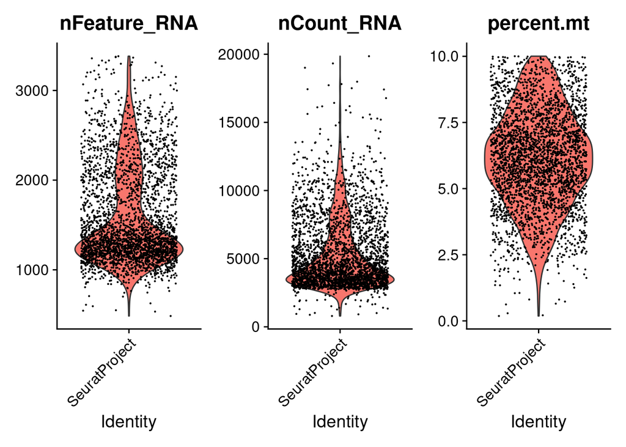

```r
# Creating a violin plot to visualize the distribution of the features to the percent mitochondrial genes
VlnPlot(phpb,
        features = c("nFeature_RNA", "nCount_RNA", "percent.mt"), ncol = 3)
```

```r
# The vioin plots indicate that the counts and features occurr at higher frequencies around 4000 and 1200 respectively, while the mitochondrial genes make up about 6 percent of the gene expression in the cells.
```

###5. Let’s filter the data to keep cells that have greater than 200 and less than 3000 unique features and the percent mitochondrial genes is less than 7.5. (5 pts)

```r
# Using the subset function to filter the data in the Seurat object
phpb <- subset(phpb, subset = nFeature_RNA > 200 & nFeature_RNA < 3000 & percent.mt < 7.5)
```

###6. Thanks to update to the Seurat workflow, we can now run 3 steps: normalization, scaling and finding variable features with one command “SCTransform”. Refer to the seurat ([tutorial](https://satijalab.org/seurat/articles/sctransform_vignette)). Run the SCTransform with the var.to.regress option set to the “percent.mt” (10 pts)

```r
# Using the SCTransform function to normalize, scale, and find the variable features while regressing out the 'percent.mt' of into a new regression
phpb <- SCTransform(phpb, vars.to.regress = "percent.mt", verbose = FALSE)
```

## Dimension reduction

###7. - Run PCA (5 pts)

```r
# Running PCA on the object with RunPCA
phpb <- RunPCA(phpb, verbose = FALSE)
```

- use DimPlot to visualize the PCs (15 pts)
- how many cell subtypes are present in this data based on this plot? (5 pts)

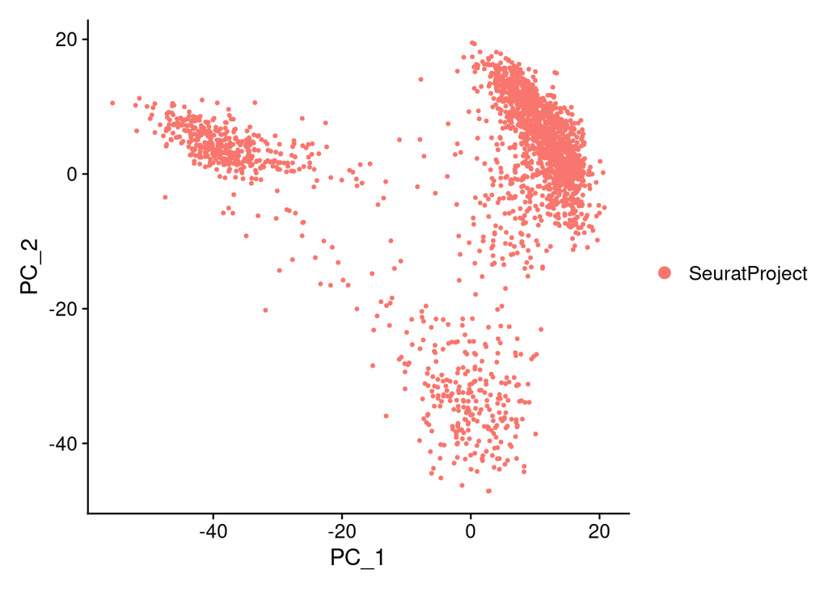

```r
# Using a DimPlot to visualize the principal components
DimPlot(object = phpb, reduction = "pca")
```

```r
# The cells are colored by their cell subtype, and the one color indicates only one cell type that these cells come from. However, there are clearly 3 different clusters of cells
```

## Clustering

###8. We will now group the cells together based on their location in the different dimensions - run FindNeighbors with the first 10 dimensions (5pts)

```r
# Running FindNeighbors to group the cells together based on their nearest neighbors in the PCA analysis
phpb <- FindNeighbors(object = phpb, dims = 1:10)
```

- run FindClusters (5 pts)

```r
# Now using FindClusters to separate the clusters by their nearest neighbor groups
phpb <- FindClusters(object = phpb, resolution = 0.5)
```

```
## Modularity Optimizer version 1.3.0 by Ludo Waltman and Nees Jan van Eck
##
## Number of nodes: 2251
## Number of edges: 69075
##
## Running Louvain algorithm...
## Maximum modularity in 10 random starts: 0.9164
## Number of communities: 11
## Elapsed time: 0 seconds
```

###9. Now that we have assigned clusters, let’s visualize these clusters - run UMAP with the first 10 dimensions (10 pts)

```r
# Running UMAP to find the kNN index from the PCA and cluster analysis
phpb <- RunUMAP(object = phpb, dims = 1:10)
```

- use DimPlot to plot the UMAP with labels (15 pts)

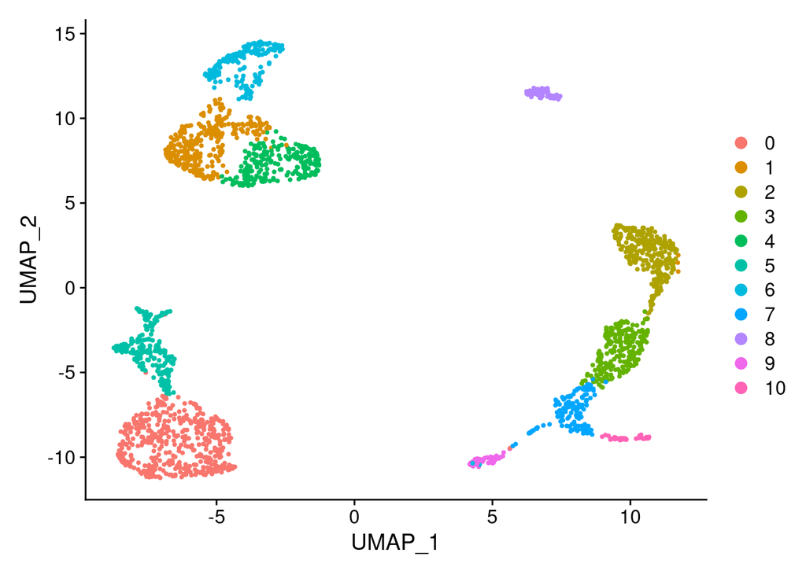

```r
# Using DimPlot to plot the UMAP clusters made by kNN analysis
DimPlot(object = phpb, reduction = "umap")
```

- how many clusters do you get (5pts)

We get 11 total clusters from running UMAP.

###10. (15 pts) We will now visualize the distribution of some gene markers across the clusters - use VlnPlot to plot make feature plot for the following features: “IL7R”,“CCR7”,“CD14”,“LYZ”,“MS4A1”,“CD8A”,“PPBP”,“NKG7”

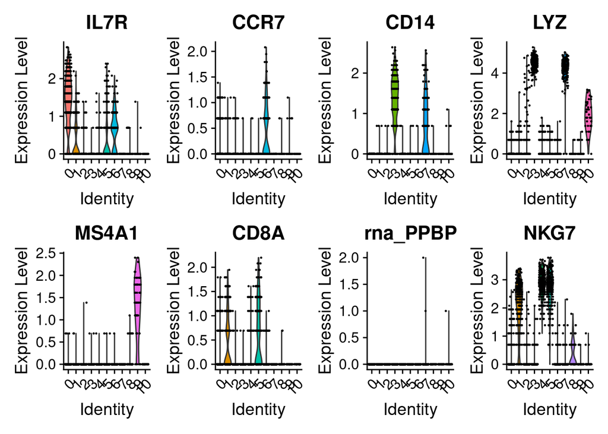

```r
# Using VlnPlot to visualize canonical markers across the clusters made by UMAP
VlnPlot(object = phpb, features = c("IL7R", "CCR7", "CD14", "LYZ", "MS4A1", "CD8A", "PPBP", "NKG7"), pt.size = 0.2, ncol = 4)
```

- does this data contain platelets? No, with the low/non-existent levels of PPBP this data does not contain platelets.
- which clusters contain CD8+ T cells? Clusters 5 and 1 contain CD8+ T cells.
- which clusters contain CD4+ T cells? Clusters 0, 1, and 6 contain CD4+ T cells.
- what cell type does cluster 9 most likely contain? Cluster 9 most likely contains B cells.